# BlogPost Boston AirBNB

##### 3.1.4 Check for missing values in rows

```python
# Identify missing rows
missingval_rows=df_listing_clean.isnull().sum(axis=1)
```

```python
missingval_rows.describe()
```

```
count    3585.000000
mean        2.323849
std         3.467202
min         0.000000
25%         0.000000
50%         0.000000
75%         4.000000
max        12.000000
dtype: float64
```

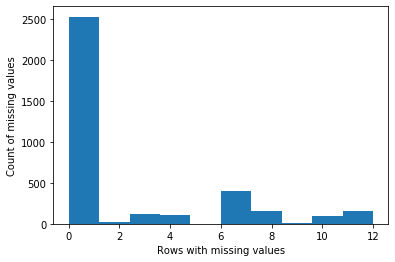

```python
#Visualize missing row values
plt.hist(missingval_rows)
plt.xlabel('Rows with missing values')
plt.ylabel('Count of missing values')
plt.show()
```

```python
#fill missing values
df_listing_clean=df_listing_clean.fillna(df_listing_clean.mode().iloc[0])
```

```python
df_listing_clean.isnull().sum(axis=1)
```

```
3307    0
780     0
855     0
2       0
2109    0
       ..
1699    0
2789    0
3278    0
176     0
1064    0
Length: 3585, dtype: int64
```

```python
df_listing_clean.shape
```

```
(3585, 31)
```

##### 3.1.5 Check categorical variables

```python
#Identify categorical variables
cat_var = df_listing_clean.select_dtypes(exclude=['int64', 'float64']).columns
```

```python
#check categorical variables
cat_var
```

```
Index(['host_response_time', 'host_response_rate', 'host_acceptance_rate',
       'host_is_superhost', 'host_identity_verified', 'neighbourhood_cleansed',
       'city', 'zipcode', 'property_type', 'room_type', 'bed_type', 'price',
       'cleaning_fee', 'extra_people', 'instant_bookable',
       'cancellation_policy'],
      dtype='object')
```

```python
#display values to see if variables are useful for analysis
for col in cat_var:
    print(df_listing_clean[col].value_counts())
```

```
within an hour        1855
within a few hours    1218
within a day           469
a few days or more      43
Name: host_response_time, dtype: int64
100%    2543
98%      195
90%      106
96%       90
89%       87
71%       62
99%       52
92%       38
80%       38
97%       36
94%       28
70%       23
95%       22
50%       21
93%       18
79%       18
77%       17
91%       17
73%       16
67%       15
60%       15
75%       14
0%        13
86%       11
83%       10
78%       10
81%        8
85%        7
69%        7
88%        6
33%        6
40%        5
36%        3
82%        3
30%        3
```

[output cut: 238 more lines]

```
$6.00         1
$85.00        1
$89.00        1
$125.00       1
$58.00        1
$120.00       1
Name: extra_people, dtype: int64
f    2991
t     594
Name: instant_bookable, dtype: int64
strict             1582
flexible            999
moderate            919
super_strict_30      85
Name: cancellation_policy, dtype: int64
```

```python
#from the data displayed above,the following variables seem redundant for the purpose of my analysis.
#I will  use one variable for host responsiveness - 'host_response_time'
#It looks like zipcode and city are redundant variables with 'neighbourhood_cleansed' variable
df_listing_clean = df_listing_clean.drop(['host_response_rate','host_acceptance_rate','zipcode','city'],axis=1)

cat_var = df_listing_clean.select_dtypes(exclude=['int64', 'float64']).columns
```

```python
cat_var
```

```
Index(['host_response_time', 'host_is_superhost', 'host_identity_verified',
       'neighbourhood_cleansed', 'property_type', 'room_type', 'bed_type',
       'price', 'cleaning_fee', 'extra_people', 'instant_bookable',
       'cancellation_policy'],
      dtype='object')
```

```python
df_listing_clean.shape
```

```
(3585, 27)
```

###### 3.1.5.1 Check counts of each variable, to see which variable need re-encoding

```python
def plot_cat(col, df):
    '''Takes the column name and dataframe, returns the counts and percentage'''
    pct_cnt = pd.DataFrame(df.groupby(col)[col].count())
    pct_cnt['PercentStatus'] = (pct_cnt[col]/pct_cnt[col].sum())*100
    pct_cnt.sort_values(by='PercentStatus', ascending=False)

    return pct_cnt
```

```python
plot_cat('host_response_time',df_listing_clean)
```

| host_response_time | host_response_time | PercentStatus |
| --- | --- | --- |
| a few days or more | 43 | 1.199442 |
| within a day | 469 | 13.082287 |
| within a few hours | 1218 | 33.974895 |
| within an hour | 1855 | 51.743375 |

```python
#Use Scikit-Learn Label Encoder, add new column for re-encoded values
from sklearn.preprocessing import LabelEncoder

lb_cat = LabelEncoder()
df_listing_clean['host_response_time_code'] = lb_cat.fit_transform(df_listing_clean["host_response_time"])
df_listing_clean[['host_response_time', 'host_response_time_code']].head(10)
```

|  | host_response_time | host_response_time_code |
| --- | --- | --- |
| 3307 | within a few hours | 2 |
| 780 | within a day | 1 |
| 855 | within a day | 1 |
| 2 | within a few hours | 2 |
| 2109 | within a few hours | 2 |
| 1544 | within a day | 1 |
| 920 | within a few hours | 2 |
| 1251 | within a few hours | 2 |
| 2311 | within a few hours | 2 |
| 1260 | within a few hours | 2 |

```python
plot_cat('host_is_superhost',df_listing_clean)
```

| host_is_superhost | host_is_superhost | PercentStatus |
| --- | --- | --- |
| f | 3178 | 88.647141 |
| t | 407 | 11.352859 |

```python
df_listing_clean['host_is_superhost_code'] = lb_cat.fit_transform(df_listing_clean["host_is_superhost"])
df_listing_clean[['host_is_superhost', 'host_is_superhost_code']].head(10)
```

|  | host_is_superhost | host_is_superhost_code |
| --- | --- | --- |
| 3307 | f | 0 |
| 780 | f | 0 |
| 855 | f | 0 |
| 2 | t | 1 |
| 2109 | f | 0 |
| 1544 | f | 0 |
| 920 | f | 0 |
| 1251 | f | 0 |
| 2311 | f | 0 |
| 1260 | f | 0 |

```python
plot_cat('host_identity_verified',df_listing_clean)
```

| host_identity_verified | host_identity_verified | PercentStatus |
| --- | --- | --- |
| f | 982 | 27.391911 |
| t | 2603 | 72.608089 |

```python
df_listing_clean['host_identity_verified_code'] = lb_cat.fit_transform(df_listing_clean["host_identity_verified"])
df_listing_clean[['host_identity_verified', 'host_identity_verified_code']].head(10)
```

|  | host_identity_verified | host_identity_verified_code |
| --- | --- | --- |
| 3307 | t | 1 |
| 780 | t | 1 |
| 855 | t | 1 |
| 2 | t | 1 |
| 2109 | f | 0 |
| 1544 | f | 0 |
| 920 | t | 1 |
| 1251 | t | 1 |
| 2311 | t | 1 |
| 1260 | t | 1 |

```python
plot_cat('neighbourhood_cleansed',df_listing_clean)
```

| neighbourhood_cleansed | neighbourhood_cleansed | PercentStatus |
| --- | --- | --- |
| Allston | 260 | 7.252441 |
| Back Bay | 302 | 8.423989 |
| Bay Village | 24 | 0.669456 |
| Beacon Hill | 194 | 5.411437 |
| Brighton | 185 | 5.160391 |
| Charlestown | 111 | 3.096234 |
| Chinatown | 71 | 1.980474 |
| Dorchester | 269 | 7.503487 |
| Downtown | 172 | 4.797768 |
| East Boston | 150 | 4.184100 |
| Fenway | 290 | 8.089261 |
| Hyde Park | 31 | 0.864714 |
| Jamaica Plain | 343 | 9.567643 |
| Leather District | 5 | 0.139470 |
| Longwood Medical Area | 9 | 0.251046 |
| Mattapan | 24 | 0.669456 |
| Mission Hill | 124 | 3.458856 |
| North End | 143 | 3.988842 |
| Roslindale | 56 | 1.562064 |
| Roxbury | 144 | 4.016736 |
| South Boston | 174 | 4.853556 |
| South Boston Waterfront | 83 | 2.315202 |
| South End | 326 | 9.093445 |
| West End | 49 | 1.366806 |
| West Roxbury | 46 | 1.283124 |

```python
df_listing_clean['neighbourhood_cleansed_code'] = lb_cat.fit_transform(df_listing_clean["neighbourhood_cleansed"])
df_listing_clean[['neighbourhood_cleansed', 'neighbourhood_cleansed_code']].head(10)
```

|  | neighbourhood_cleansed | neighbourhood_cleansed_code |
| --- | --- | --- |
| 3307 | Allston | 0 |
| 780 | Roxbury | 19 |
| 855 | Roxbury | 19 |
| 2 | Roslindale | 18 |
| 2109 | Downtown | 8 |
| 1544 | East Boston | 9 |
| 920 | South End | 22 |
| 1251 | Back Bay | 1 |
| 2311 | Fenway | 10 |
| 1260 | Back Bay | 1 |

```python
plot_cat('property_type',df_listing_clean)
```

| property_type | property_type | PercentStatus |
| --- | --- | --- |
| Apartment | 2615 | 72.942817 |
| Bed & Breakfast | 41 | 1.143654 |
| Boat | 12 | 0.334728 |
| Camper/RV | 1 | 0.027894 |
| Condominium | 231 | 6.443515 |
| Dorm | 2 | 0.055788 |
| Entire Floor | 4 | 0.111576 |
| Guesthouse | 1 | 0.027894 |
| House | 562 | 15.676430 |
| Loft | 39 | 1.087866 |
| Other | 17 | 0.474198 |
| Townhouse | 54 | 1.506276 |
| Villa | 6 | 0.167364 |

```python
df_listing_clean['property_type_code'] = lb_cat.fit_transform(df_listing_clean["property_type"])
df_listing_clean[['property_type', 'property_type_code']].head(10)
```

|  | property_type | property_type_code |
| --- | --- | --- |
| 3307 | Apartment | 0 |
| 780 | House | 8 |
| 855 | Apartment | 0 |
| 2 | Apartment | 0 |
| 2109 | Apartment | 0 |
| 1544 | Apartment | 0 |
| 920 | Apartment | 0 |
| 1251 | Apartment | 0 |
| 2311 | Apartment | 0 |
| 1260 | Apartment | 0 |

```python
plot_cat('room_type',df_listing_clean)
```

| room_type | room_type | PercentStatus |
| --- | --- | --- |
| Entire home/apt | 2127 | 59.330544 |
| Private room | 1378 | 38.437936 |
| Shared room | 80 | 2.231520 |

```python
df_listing_clean['room_type_code'] = lb_cat.fit_transform(df_listing_clean["room_type"])
df_listing_clean[['room_type', 'room_type_code']].head(10)
```

|  | room_type | room_type_code |
| --- | --- | --- |
| 3307 | Private room | 1 |
| 780 | Private room | 1 |
| 855 | Entire home/apt | 0 |
| 2 | Private room | 1 |
| 2109 | Entire home/apt | 0 |
| 1544 | Entire home/apt | 0 |
| 920 | Entire home/apt | 0 |
| 1251 | Entire home/apt | 0 |
| 2311 | Entire home/apt | 0 |
| 1260 | Entire home/apt | 0 |

```python
plot_cat('bed_type',df_listing_clean)
```

| bed_type | bed_type | PercentStatus |
| --- | --- | --- |
| Airbed | 40 | 1.115760 |
| Couch | 10 | 0.278940 |
| Futon | 51 | 1.422594 |
| Pull-out Sofa | 31 | 0.864714 |
| Real Bed | 3453 | 96.317992 |

```python
df_listing_clean['bed_type_code'] = lb_cat.fit_transform(df_listing_clean["bed_type"])
df_listing_clean[['bed_type', 'bed_type_code']].head(10)
```

|  | bed_type | bed_type_code |
| --- | --- | --- |
| 3307 | Real Bed | 4 |
| 780 | Real Bed | 4 |
| 855 | Real Bed | 4 |
| 2 | Real Bed | 4 |
| 2109 | Real Bed | 4 |
| 1544 | Real Bed | 4 |
| 920 | Real Bed | 4 |
| 1251 | Real Bed | 4 |
| 2311 | Real Bed | 4 |
| 1260 | Real Bed | 4 |

```python
plot_cat('price',df_listing_clean)
```

| price | price | PercentStatus |
| --- | --- | --- |
| $1,000.00 | 2 | 0.055788 |
| $1,235.00 | 1 | 0.027894 |
| $1,250.00 | 2 | 0.055788 |
| $1,275.00 | 1 | 0.027894 |
| $1,300.00 | 1 | 0.027894 |
| ... | ... | ... |
| $97.00 | 4 | 0.111576 |
| $975.00 | 1 | 0.027894 |
| $98.00 | 6 | 0.167364 |
| $99.00 | 70 | 1.952580 |
| $999.00 | 1 | 0.027894 |

324 rows × 2 columns

```python
#create function to clean up price variable,so i can re-use to clean up similar variables
def strip_dollar(column_name, dataset_name):
    '''Takes the column name and dataframe, returns the column value without the $sign'''
    dataset_name[column_name] = dataset_name[column_name].str.replace('$','').str.replace(',','');
```

```python
def conv_numeric(column_name, dataset_name):
    '''Takes the column name and dataframe, returns converted column to numeric'''
    dataset_name[column_name] = pd.to_numeric(dataset_name[column_name]);
```

```python
strip_dollar('price', df_listing_clean)
conv_numeric('price', df_listing_clean)
```

```python
plot_cat('price',df_listing_clean)
```

| price | price | PercentStatus |
| --- | --- | --- |
| 10.0 | 1 | 0.027894 |
| 11.0 | 1 | 0.027894 |
| 20.0 | 2 | 0.055788 |
| 22.0 | 2 | 0.055788 |
| 25.0 | 3 | 0.083682 |
| ... | ... | ... |
| 1345.0 | 1 | 0.027894 |
| 1372.0 | 1 | 0.027894 |
| 1400.0 | 1 | 0.027894 |
| 3000.0 | 1 | 0.027894 |
| 4000.0 | 1 | 0.027894 |

324 rows × 2 columns

```python
plot_cat('cleaning_fee',df_listing_clean)
```

| cleaning_fee | cleaning_fee | PercentStatus |
| --- | --- | --- |
| $10.00 | 131 | 3.654114 |
| $100.00 | 1460 | 40.725244 |
| $105.00 | 1 | 0.027894 |
| $110.00 | 4 | 0.111576 |
| $115.00 | 3 | 0.083682 |
| ... | ... | ... |
| $85.00 | 28 | 0.781032 |
| $9.00 | 3 | 0.083682 |
| $90.00 | 18 | 0.502092 |
| $95.00 | 79 | 2.203626 |
| $99.00 | 14 | 0.390516 |

79 rows × 2 columns

```python
strip_dollar('cleaning_fee', df_listing_clean)
conv_numeric('cleaning_fee', df_listing_clean)
```

```python
plot_cat('cleaning_fee',df_listing_clean)
```

| cleaning_fee | cleaning_fee | PercentStatus |
| --- | --- | --- |
| 5.0 | 44 | 1.227336 |
| 6.0 | 4 | 0.111576 |
| 7.0 | 3 | 0.083682 |
| 8.0 | 7 | 0.195258 |
| 9.0 | 3 | 0.083682 |
| ... | ... | ... |
| 200.0 | 42 | 1.171548 |
| 225.0 | 52 | 1.450488 |
| 230.0 | 1 | 0.027894 |
| 250.0 | 15 | 0.418410 |
| 300.0 | 2 | 0.055788 |

79 rows × 2 columns

```python
plot_cat('extra_people',df_listing_clean)
```

| extra_people | extra_people | PercentStatus |
| --- | --- | --- |
| $0.00 | 2211 | 61.673640 |
| $10.00 | 212 | 5.913529 |
| $100.00 | 33 | 0.920502 |
| $12.00 | 8 | 0.223152 |
| $120.00 | 1 | 0.027894 |
| $125.00 | 1 | 0.027894 |
| $15.00 | 136 | 3.793584 |
| $150.00 | 4 | 0.111576 |
| $16.00 | 2 | 0.055788 |
| $17.00 | 6 | 0.167364 |
| $18.00 | 2 | 0.055788 |
| $19.00 | 4 | 0.111576 |
| $20.00 | 237 | 6.610879 |
| $200.00 | 3 | 0.083682 |
| $22.00 | 3 | 0.083682 |
| $24.00 | 6 | 0.167364 |
| $25.00 | 277 | 7.726639 |
| $27.00 | 2 | 0.055788 |
| $29.00 | 2 | 0.055788 |
| $30.00 | 79 | 2.203626 |
| $33.00 | 1 | 0.027894 |
| $34.00 | 2 | 0.055788 |
| $35.00 | 48 | 1.338912 |
| $36.00 | 2 | 0.055788 |
| $37.00 | 4 | 0.111576 |
| $39.00 | 7 | 0.195258 |
| $40.00 | 42 | 1.171548 |
| $42.00 | 1 | 0.027894 |
| $44.00 | 1 | 0.027894 |
| $45.00 | 19 | 0.529986 |
| $49.00 | 7 | 0.195258 |
| $5.00 | 27 | 0.753138 |
| $50.00 | 145 | 4.044630 |
| $55.00 | 2 | 0.055788 |
| $58.00 | 1 | 0.027894 |
| $59.00 | 2 | 0.055788 |
| $6.00 | 1 | 0.027894 |
| $60.00 | 6 | 0.167364 |
| $62.00 | 1 | 0.027894 |
| $65.00 | 3 | 0.083682 |
| $69.00 | 1 | 0.027894 |
| $7.00 | 4 | 0.111576 |
| $70.00 | 7 | 0.195258 |
| $75.00 | 9 | 0.251046 |
| $77.00 | 1 | 0.027894 |
| $8.00 | 4 | 0.111576 |
| $80.00 | 3 | 0.083682 |
| $85.00 | 1 | 0.027894 |
| $88.00 | 1 | 0.027894 |
| $89.00 | 1 | 0.027894 |
| $9.00 | 2 | 0.055788 |

```python
strip_dollar('extra_people', df_listing_clean)
conv_numeric('extra_people', df_listing_clean)
```

```python
plot_cat('extra_people',df_listing_clean)
```

| extra_people | extra_people | PercentStatus |
| --- | --- | --- |
| 0.0 | 2211 | 61.673640 |
| 5.0 | 27 | 0.753138 |
| 6.0 | 1 | 0.027894 |
| 7.0 | 4 | 0.111576 |
| 8.0 | 4 | 0.111576 |
| 9.0 | 2 | 0.055788 |
| 10.0 | 212 | 5.913529 |
| 12.0 | 8 | 0.223152 |
| 15.0 | 136 | 3.793584 |
| 16.0 | 2 | 0.055788 |
| 17.0 | 6 | 0.167364 |
| 18.0 | 2 | 0.055788 |
| 19.0 | 4 | 0.111576 |
| 20.0 | 237 | 6.610879 |
| 22.0 | 3 | 0.083682 |
| 24.0 | 6 | 0.167364 |
| 25.0 | 277 | 7.726639 |
| 27.0 | 2 | 0.055788 |
| 29.0 | 2 | 0.055788 |
| 30.0 | 79 | 2.203626 |
| 33.0 | 1 | 0.027894 |
| 34.0 | 2 | 0.055788 |
| 35.0 | 48 | 1.338912 |
| 36.0 | 2 | 0.055788 |
| 37.0 | 4 | 0.111576 |
| 39.0 | 7 | 0.195258 |
| 40.0 | 42 | 1.171548 |
| 42.0 | 1 | 0.027894 |
| 44.0 | 1 | 0.027894 |
| 45.0 | 19 | 0.529986 |
| 49.0 | 7 | 0.195258 |
| 50.0 | 145 | 4.044630 |
| 55.0 | 2 | 0.055788 |
| 58.0 | 1 | 0.027894 |
| 59.0 | 2 | 0.055788 |
| 60.0 | 6 | 0.167364 |
| 62.0 | 1 | 0.027894 |
| 65.0 | 3 | 0.083682 |
| 69.0 | 1 | 0.027894 |
| 70.0 | 7 | 0.195258 |
| 75.0 | 9 | 0.251046 |
| 77.0 | 1 | 0.027894 |
| 80.0 | 3 | 0.083682 |
| 85.0 | 1 | 0.027894 |
| 88.0 | 1 | 0.027894 |
| 89.0 | 1 | 0.027894 |
| 100.0 | 33 | 0.920502 |
| 120.0 | 1 | 0.027894 |
| 125.0 | 1 | 0.027894 |
| 150.0 | 4 | 0.111576 |
| 200.0 | 3 | 0.083682 |

```python
plot_cat('instant_bookable',df_listing_clean)
```

| instant_bookable | instant_bookable | PercentStatus |
| --- | --- | --- |
| f | 2991 | 83.430962 |
| t | 594 | 16.569038 |

```python
df_listing_clean['instant_bookable_code'] = lb_cat.fit_transform(df_listing_clean["instant_bookable"])
df_listing_clean[['instant_bookable', 'instant_bookable_code']].head(10)
```

|  | instant_bookable | instant_bookable_code |
| --- | --- | --- |
| 3307 | f | 0 |
| 780 | f | 0 |
| 855 | f | 0 |
| 2 | f | 0 |
| 2109 | f | 0 |
| 1544 | f | 0 |
| 920 | f | 0 |
| 1251 | f | 0 |
| 2311 | f | 0 |
| 1260 | f | 0 |

```python
plot_cat('cancellation_policy',df_listing_clean)
```

| cancellation_policy | cancellation_policy | PercentStatus |
| --- | --- | --- |
| flexible | 999 | 27.866109 |
| moderate | 919 | 25.634589 |
| strict | 1582 | 44.128312 |
| super_strict_30 | 85 | 2.370990 |

```python
df_listing_clean['cancellation_policy_code'] = lb_cat.fit_transform(df_listing_clean["cancellation_policy"])
df_listing_clean[['cancellation_policy', 'cancellation_policy_code']].head(10)
```

|  | cancellation_policy | cancellation_policy_code |
| --- | --- | --- |
| 3307 | strict | 2 |
| 780 | strict | 2 |
| 855 | strict | 2 |
| 2 | moderate | 1 |
| 2109 | moderate | 1 |
| 1544 | super_strict_30 | 3 |
| 920 | super_strict_30 | 3 |
| 1251 | super_strict_30 | 3 |
| 2311 | super_strict_30 | 3 |
| 1260 | super_strict_30 | 3 |

```python
df_listing_clean.shape
```

```
(3585, 36)
```

All categorical values were transformed using Scikit-Learn Label Encoder. I chose this method to add new column for re-encoded values, so that I will not loose the original values that I will use for visualization. I also use function to cleanup variables with prices values, so i can re-use the function to cleanup same variables type and value.

#### 3.2 Assessment of Calendar Data

```python
#look at calendar info again
df_calendar_clean.info()
```

```
<class 'pandas.core.frame.DataFrame'>
RangeIndex: 1308890 entries, 0 to 1308889
Data columns (total 4 columns):
 #   Column      Non-Null Count    Dtype
---  ------      --------------    -----
 0   listing_id  1308890 non-null  int64
 1   date        1308890 non-null  object
 2   available   1308890 non-null  object
 3   price       643037 non-null   object
dtypes: int64(1), object(3)
memory usage: 39.9+ MB
```

Calendar data has 3 categorical variables and one numeric variable. I will focus on assesment and cleanup of 3 categorical variables.

##### 3.2.1 Checking missing values

```python
display(df_calendar_clean.isnull().sum())
```

```
listing_id         0
date               0
available          0
price         665853
dtype: int64
```

```python
df_calendar_clean.shape
```

```
(1308890, 4)
```

```python
missingcalvalues=df_calendar_clean.isnull().sum()
missingcalvalues.sort_values(ascending=True,inplace=True)
missingcalvalues
```

```
listing_id         0
date               0
available          0
price         665853
dtype: int64
```

```python
missingcalvalues=missingcalvalues[missingcalvalues>0]/(df_calendar_clean.shape[0])*100
```

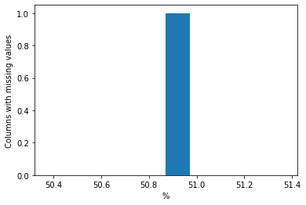

```python
# display in histogram
plt.hist(missingcalvalues)
plt.xlabel('%')
plt.ylabel('Columns with missing values')
plt.show()
```

There is only one variable that contains more than 50% missing values, which is the price. I decided not to drop this column even though is has more than 50% missing values, I will include the price in my analysis.

##### 3.2.2 Checking for missing values in rows

```python
missingcalval_rows=df_calendar_clean.isnull().sum(axis=1)
```

```python
missingcalval_rows.describe()
```

```
count    1.308890e+06
mean     5.087158e-01
std      4.999242e-01
min      0.000000e+00
25%      0.000000e+00
50%      1.000000e+00
75%      1.000000e+00
max      1.000000e+00
dtype: float64
```

```python
missingcalval_rows
```

```
0          1
1          1
2          1
3          1
4          1
          ..
1308885    1
1308886    1
1308887    1
1308888    1
1308889    1
Length: 1308890, dtype: int64
```

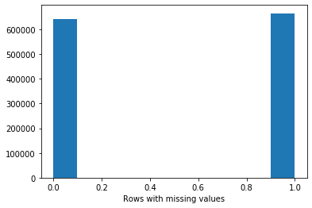

```python
plt.hist(missingcalval_rows)
plt.xlabel('Rows with missing values')
plt.show()
```

```python
#the missing values for each row is most likely the price variable,
#since i am including this analysis, I will fill in the missing value
df_calendar_clean=df_calendar_clean.fillna(df_calendar_clean.mode().iloc[0])
```

```python
df_calendar_clean.isnull().sum(axis=1)
```

```
0          0
1          0
2          0
3          0
4          0
          ..
1308885    0
1308886    0
1308887    0
1308888    0
1308889    0
Length: 1308890, dtype: int64
```

```python
df_calendar_clean.info()
```

```
<class 'pandas.core.frame.DataFrame'>
RangeIndex: 1308890 entries, 0 to 1308889
Data columns (total 4 columns):
 #   Column      Non-Null Count    Dtype
---  ------      --------------    -----
 0   listing_id  1308890 non-null  int64
 1   date        1308890 non-null  object
 2   available   1308890 non-null  object
 3   price       1308890 non-null  object
dtypes: int64(1), object(3)
memory usage: 39.9+ MB
```

```python
plot_cat('available',df_calendar_clean)
```

| available | available | PercentStatus |
| --- | --- | --- |
| f | 665853 | 50.871578 |
| t | 643037 | 49.128422 |

```python
#apply the same process to transform
df_calendar_clean['available_code'] = lb_cat.fit_transform(df_calendar_clean["available"])
df_calendar_clean[['available', 'available_code']].head(10)
```

|  | available | available_code |
| --- | --- | --- |
| 0 | f | 0 |
| 1 | f | 0 |
| 2 | f | 0 |
| 3 | f | 0 |
| 4 | f | 0 |
| 5 | f | 0 |
| 6 | f | 0 |
| 7 | f | 0 |
| 8 | f | 0 |
| 9 | f | 0 |

```python
plot_cat('date',df_calendar_clean)
```

| date | date | PercentStatus |
| --- | --- | --- |
| 2016-09-06 | 3586 | 0.273973 |
| 2016-09-07 | 3586 | 0.273973 |
| 2016-09-08 | 3586 | 0.273973 |
| 2016-09-09 | 3586 | 0.273973 |
| 2016-09-10 | 3586 | 0.273973 |
| ... | ... | ... |
| 2017-09-01 | 3586 | 0.273973 |
| 2017-09-02 | 3586 | 0.273973 |
| 2017-09-03 | 3586 | 0.273973 |
| 2017-09-04 | 3586 | 0.273973 |
| 2017-09-05 | 3586 | 0.273973 |

365 rows × 2 columns

```python
plot_cat('price',df_calendar_clean)
```

| price | price | PercentStatus |
| --- | --- | --- |
| $1,000.00 | 460 | 0.035144 |
| $1,002.00 | 5 | 0.000382 |
| $1,004.00 | 1 | 0.000076 |
| $1,006.00 | 1 | 0.000076 |
| $1,007.00 | 3 | 0.000229 |
| ... | ... | ... |
| $993.00 | 3 | 0.000229 |
| $995.00 | 69 | 0.005272 |
| $997.00 | 1 | 0.000076 |
| $998.00 | 2 | 0.000153 |
| $999.00 | 777 | 0.059363 |

1246 rows × 2 columns

```python
strip_dollar('price', df_calendar_clean)
conv_numeric('price', df_calendar_clean)
```

```python
plot_cat('price',df_calendar_clean)
```

| price | price | PercentStatus |
| --- | --- | --- |
| 11.0 | 2 | 0.000153 |
| 20.0 | 485 | 0.037054 |
| 22.0 | 178 | 0.013599 |
| 25.0 | 362 | 0.027657 |
| 27.0 | 77 | 0.005883 |
| ... | ... | ... |
| 3000.0 | 6 | 0.000458 |
| 3051.0 | 1 | 0.000076 |
| 3314.0 | 1 | 0.000076 |
| 4000.0 | 336 | 0.025671 |
| 7163.0 | 1 | 0.000076 |

1246 rows × 2 columns

To cleanup calendar data set, I followed the same process and fucntionalities to cleanup the data. I decided to retain the price variable even it has more than 50% missing values, because I want to see the price difference by date.

#### Step 4 - Answer the business questions posted above

##### 4.1 Q1: What features or variables that will show popular listing?

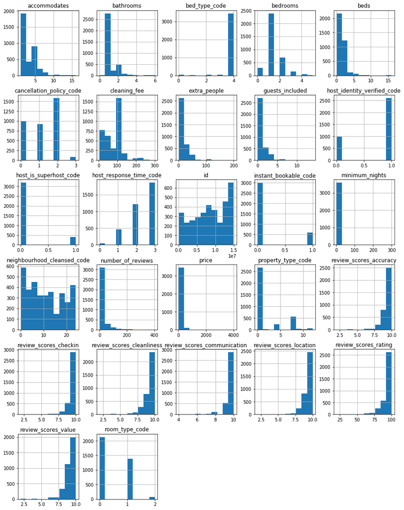

```python
#use histogram plot to see groupings
df_listing_clean.hist(figsize=(15,20));
```

```python
#List categorical variables for easy reading of variable names
cat_var
```

```
Index(['host_response_time', 'host_is_superhost', 'host_identity_verified',
       'neighbourhood_cleansed', 'property_type', 'room_type', 'bed_type',
       'price', 'cleaning_fee', 'extra_people', 'instant_bookable',
       'cancellation_policy'],
      dtype='object')
```

Plot variables using bar chart to show description of most popular listing

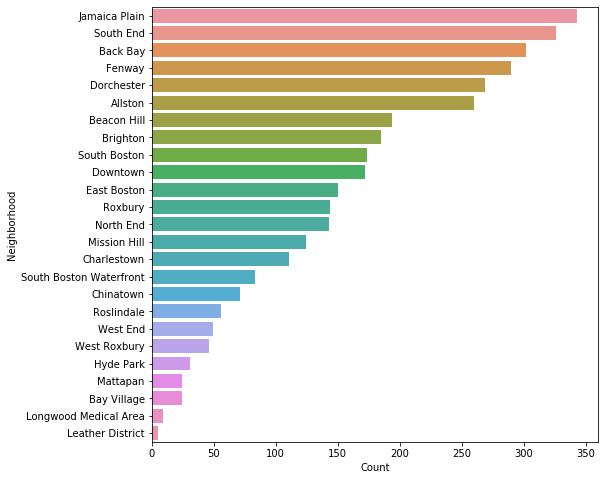

```python
#Neigborhood
plt.figure(figsize=[8, 8])

# Order the categorical variable type
cat_order = df_listing_clean['neighbourhood_cleansed'].value_counts().index

sns.countplot(data = df_listing_clean, y = 'neighbourhood_cleansed', order=cat_order)
plt.ylabel('Neighborhood')
plt.xlabel('Count');
```

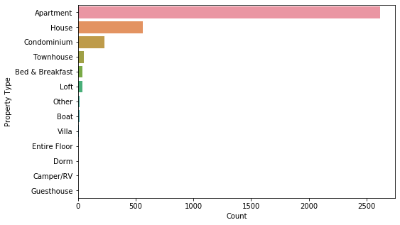

```python
# Property Type
plt.figure(figsize=[8, 5])

# Order the categorical variable type
cat_order = df_listing_clean['property_type'].value_counts().index

sns.countplot(data = df_listing_clean, y = 'property_type', order=cat_order)
plt.ylabel('Property Type')
plt.xlabel('Count');
```

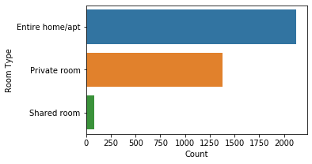

```python
#Room Type
plt.figure(figsize=[5, 3])

# Order the categorical variable type
cat_order = df_listing_clean['room_type'].value_counts().index

sns.countplot(data = df_listing_clean, y = 'room_type', order=cat_order)
plt.ylabel('Room Type')
plt.xlabel('Count');
```

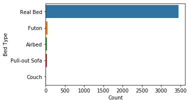

```python
#Bed Type
plt.figure(figsize=[5, 3])

# Order the categorical variable type
cat_order = df_listing_clean['bed_type'].value_counts().index

sns.countplot(data = df_listing_clean, y = 'bed_type', order=cat_order)
plt.ylabel('Bed Type')
plt.xlabel('Count');
```

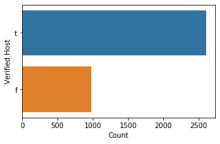

```python
#host_identity_verified
plt.figure(figsize=[5, 3])

# Order the categorical variable type
cat_order = df_listing_clean['host_identity_verified'].value_counts().index

sns.countplot(data = df_listing_clean, y = 'host_identity_verified', order=cat_order)
plt.ylabel('Verified Host')
plt.xlabel('Count');
```

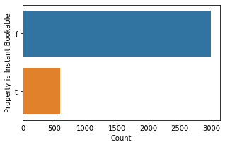

```python
#instant_bookable
plt.figure(figsize=[5, 3])

# Order the categorical variable type
cat_order = df_listing_clean['instant_bookable'].value_counts().index

sns.countplot(data = df_listing_clean, y = 'instant_bookable', order=cat_order)
plt.ylabel('Property is Instant Bookable')
plt.xlabel('Count');
```

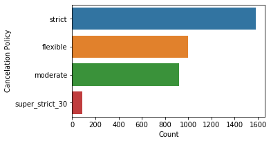

```python
#cancellation_policy
plt.figure(figsize=[5, 3])

# Order the categorical variable type
cat_order = df_listing_clean['cancellation_policy'].value_counts().index

sns.countplot(data = df_listing_clean, y = 'cancellation_policy', order=cat_order)
plt.ylabel('Cancelation Policy')
plt.xlabel('Count');
```

The graphs above showed that Apartment is the most represented property type, and Real Bed is the most represented bed type. About 72% of Host's identity are verified. Cancellation property and if property is bookable instantly seem to be stringent. The neighborhood with most listings are Jamaica Plain and South End.

##### 4.2 Q2: What available data that would indicate high review score?

```python
#list numeric
numeric_var = df_listing_clean.select_dtypes(exclude=['object']).columns
```

```python
numeric_var
```

```
Index(['id', 'accommodates', 'bathrooms', 'bedrooms', 'beds', 'price',
       'cleaning_fee', 'guests_included', 'extra_people', 'minimum_nights',
       'number_of_reviews', 'review_scores_rating', 'review_scores_accuracy',
       'review_scores_cleanliness', 'review_scores_checkin',
       'review_scores_communication', 'review_scores_location',
       'review_scores_value', 'host_response_time_code',
       'host_is_superhost_code', 'host_identity_verified_code',
       'neighbourhood_cleansed_code', 'property_type_code', 'room_type_code',
       'bed_type_code', 'instant_bookable_code', 'cancellation_policy_code'],
      dtype='object')
```

Use Heatmap Correlation plot to see if variables have correlation to high review score. Based on histogram above, variables related to reviews show similar groupings. So, I will just use number of reviews and reviews scores rating

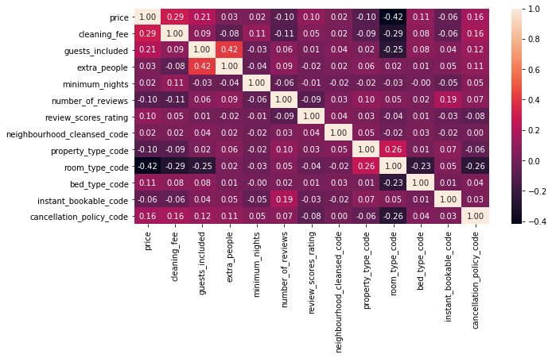

```python
select_var = [ 'price','cleaning_fee', 'guests_included', 'extra_people',
              'minimum_nights','number_of_reviews', 'review_scores_rating',
              'neighbourhood_cleansed_code', 'property_type_code', 'room_type_code',
              'bed_type_code', 'instant_bookable_code', 'cancellation_policy_code']

plt.figure(figsize = [10, 5])
sns.heatmap(df_listing_clean[select_var].corr(), annot = True, fmt = '.2f')
plt.show()
```

The heatmap doesn't show any significant correlation to the high review scores.

#### 4.3 Q3: Which features could have impact to better or higher rates?

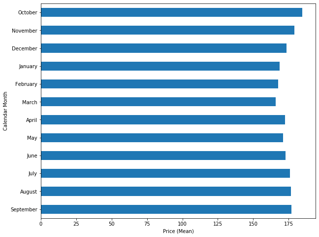

```python
#first lets look at calendar, to see which months have higher rates
df_calendar_clean['Month'] = pd.to_datetime(df_calendar_clean['date'])
df_calendar_clean = df_calendar_clean.sort_values('Month', ascending=False)
month_mean = df_calendar_clean.groupby(df_calendar_clean['Month'].dt.strftime('%B'), sort=False)['price'].mean()
month_mean.plot(kind = 'barh', figsize = (10,8));
plt.xlabel('Price (Mean)')
plt.ylabel('Calendar Month')
plt.show()
```

The graph shows that Fall Season (October, November) have higher rates, and price decreases during winter season

##### 4.3.1 Plot mean price by popular attributes

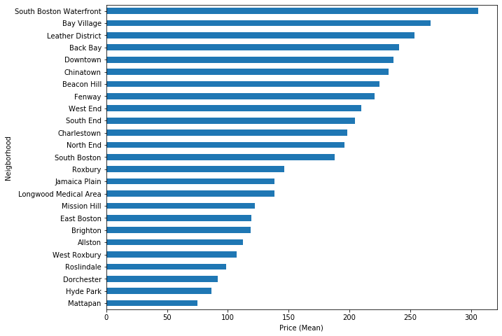

```python
#Plot mean price by neighborhood
neighborhood_mean = df_listing_clean.groupby(df_listing_clean['neighbourhood_cleansed'])['price'].mean()
neighborhood_mean.sort_values(ascending=True,inplace=True)
neighborhood_mean.plot(kind = 'barh', figsize = (10,8));
plt.xlabel('Price (Mean)')
plt.ylabel('Neigborhood')
plt.show()
```

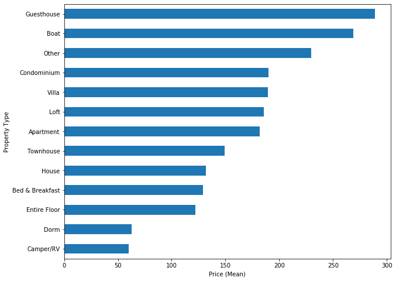

```python
#Plot mean price by property type
property_type_mean = df_listing_clean.groupby(df_listing_clean['property_type'])['price'].mean()
property_type_mean.sort_values(ascending=True,inplace=True)
property_type_mean.plot(kind = 'barh', figsize = (10,8));
plt.xlabel('Price (Mean)')
plt.ylabel('Property Type')
plt.show()
```

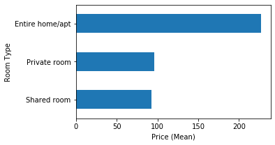

```python
#Plot mean price by room type
room_type_mean = df_listing_clean.groupby(df_listing_clean['room_type'])['price'].mean()
room_type_mean.sort_values(ascending=True,inplace=True)
room_type_mean.plot(kind = 'barh', figsize = (5,3));
plt.xlabel('Price (Mean)')
plt.ylabel('Room Type')
plt.show()
```

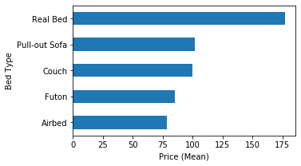

```python
#Plot mean price by bed type
bed_type_mean = df_listing_clean.groupby(df_listing_clean['bed_type'])['price'].mean()
bed_type_mean.sort_values(ascending=True,inplace=True)
bed_type_mean.plot(kind = 'barh', figsize = (5,3));
plt.xlabel('Price (Mean)')
plt.ylabel('Bed Type')
plt.show()
```

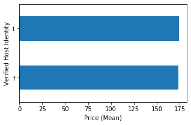

```python
#Plot mean price by host identity
host_mean = df_listing_clean.groupby(df_listing_clean['host_identity_verified'])['price'].mean()
host_mean.sort_values(ascending=True,inplace=True)
host_mean.plot(kind = 'barh', figsize = (5,3));
plt.xlabel('Price (Mean)')
plt.ylabel('Verified Host Identity')
plt.show()
```

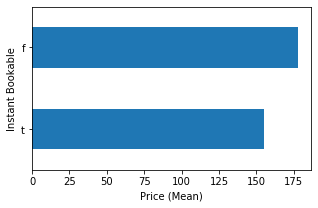

```python
#Plot mean price by bookable
bookable_mean = df_listing_clean.groupby(df_listing_clean['instant_bookable'])['price'].mean()
bookable_mean.sort_values(ascending=True,inplace=True)
bookable_mean.plot(kind = 'barh', figsize = (5,3));
plt.xlabel('Price (Mean)')
plt.ylabel('Instant Bookable')
plt.show()
```

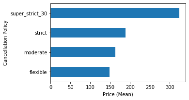

```python
#Plot mean price by cancellation policy
cancel_mean = df_listing_clean.groupby(df_listing_clean['cancellation_policy'])['price'].mean()
cancel_mean.sort_values(ascending=True,inplace=True)
cancel_mean.plot(kind = 'barh', figsize = (5,3));
plt.xlabel('Price (Mean)')
plt.ylabel('Cancellation Policy')
plt.show()
```

It looks like neighborhood, property type, room type, bed type, and cancellation policy are indicators of higher rates. Instant Bookable or if host's identity is verified doesn't indicate higher rates. The above graphs indicates higher rates but based on correlation only. Let's see if the predictive model below will reveal similar result.

##### 4.3.2 Predictive Model

```python
#import libraries needed for prediction, to determine which variables drives the prices
from sklearn.feature_extraction.text import CountVectorizer
from sklearn.model_selection import train_test_split
from sklearn.metrics import r2_score, mean_squared_error, median_absolute_error
from sklearn.ensemble import RandomForestRegressor
```

###### 4.3.2.1 Assesment and Cleanup

```python
#display variables
df_listing_clean.info()
```

```
<class 'pandas.core.frame.DataFrame'>
Int64Index: 3585 entries, 3307 to 1064
Data columns (total 36 columns):
 #   Column                       Non-Null Count  Dtype
---  ------                       --------------  -----
 0   id                           3585 non-null   int64
 1   host_response_time           3585 non-null   object
 2   host_is_superhost            3585 non-null   object
 3   host_identity_verified       3585 non-null   object
 4   neighbourhood_cleansed       3585 non-null   object
 5   property_type                3585 non-null   object
 6   room_type                    3585 non-null   object
 7   accommodates                 3585 non-null   int64
 8   bathrooms                    3585 non-null   float64
 9   bedrooms                     3585 non-null   float64
```

[output cut: 28 more lines]

The dataset contains the categorical and other variables that I don't intend to include in the analysis.

```python
# Define arrays to use
y = df_listing_clean['price']

#remove variables that will not be used
X = df_listing_clean.drop(['price','id','host_response_time', 'host_is_superhost', 'host_identity_verified',
       'neighbourhood_cleansed', 'property_type', 'room_type', 'bed_type','price', 'cleaning_fee',
        'extra_people', 'instant_bookable', 'instant_bookable_code','host_identity_verified_code',
        'review_scores_accuracy','review_scores_cleanliness','review_scores_checkin',
        'review_scores_communication','review_scores_location','review_scores_value','cancellation_policy',
        'guests_included','minimum_nights','host_response_time_code','review_scores_rating',
        'host_is_superhost_code','accommodates','number_of_reviews','bathrooms',
        'beds','bedrooms'], axis=1)
```

```python
#check if all remaining coloumns are transformed
#this should display values which have been transformed above
y
```

```
3307     40.0
780     145.0
855     195.0
2        65.0
2109    154.0
        ...
1699    190.0
2789     55.0
3278     90.0
176      49.0
1064    165.0
Name: price, Length: 3585, dtype: float64
```

```python
#check if all remaining coloumns are transformed
#this should display transformed values, which have been transformed above
X
```

|  | neighbourhood_cleansed_code | property_type_code | room_type_code | bed_type_code | cancellation_policy_code |
| --- | --- | --- | --- | --- | --- |
| 3307 | 0 | 0 | 1 | 4 | 2 |
| 780 | 19 | 8 | 1 | 4 | 2 |
| 855 | 19 | 0 | 0 | 4 | 2 |
| 2 | 18 | 0 | 1 | 4 | 1 |
| 2109 | 8 | 0 | 0 | 4 | 1 |
| ... | ... | ... | ... | ... | ... |
| 1699 | 5 | 8 | 1 | 4 | 1 |
| 2789 | 7 | 8 | 1 | 4 | 0 |
| 3278 | 20 | 0 | 1 | 4 | 2 |
| 176 | 12 | 0 | 2 | 4 | 2 |
| 1064 | 22 | 0 | 0 | 4 | 2 |

3585 rows × 5 columns

```python
#Use sklearn train_test_split split the data for test and training randomly
X_train, X_test, y_train, y_test = train_test_split(X, y, test_size = .30, random_state=62)
```

```python
#train the model with 100 Decision Trees:
ForestRegressor = RandomForestRegressor(n_estimators=100)
```

```python
#use random forest regressor to fit dataset
ForestRegressor.fit(X_train, y_train)
```

```
RandomForestRegressor(bootstrap=True, ccp_alpha=0.0, criterion='mse',
                      max_depth=None, max_features='auto', max_leaf_nodes=None,
                      max_samples=None, min_impurity_decrease=0.0,
                      min_impurity_split=None, min_samples_leaf=1,
                      min_samples_split=2, min_weight_fraction_leaf=0.0,
                      n_estimators=100, n_jobs=None, oob_score=False,
                      random_state=None, verbose=0, warm_start=False)
```

```python
#Perform Prediction using predict method
y_test_preds = ForestRegressor.predict(X_test)
y_test_preds
```

```
array([271.66788355, 146.44501129, 181.22994522, ...,  99.38046104,
       129.10509603, 244.24080049])
```

###### 4.3.2.2 Model Evaluation

```python
print(r2_score(y_test, y_test_preds))
print(mean_squared_error(y_test, y_test_preds))
print(median_absolute_error(y_test, y_test_preds))
```

```
0.27422164903851753
11736.066162880783
36.20505210639033
```

```python
#use feature_importances_ to identify features that are important
coef_df = pd.DataFrame()
coef_df['est_int'] = X_train.columns
coef_df['coefficient'] = ForestRegressor.feature_importances_
coef_df.sort_values('coefficient', ascending=False).head(20)
```

|  | est_int | coefficient |
| --- | --- | --- |
| 2 | room_type_code | 0.468768 |
| 0 | neighbourhood_cleansed_code | 0.267438 |
| 4 | cancellation_policy_code | 0.155258 |
| 1 | property_type_code | 0.093210 |
| 3 | bed_type_code | 0.015328 |

###### References:

https://www.kaggle.com/airbnb/boston

https://www.programiz.com/python-programming/docstrings

https://stackoverflow.com/questions/55937430/python-how-to-remove-sign-and-space#:~:text=You%20can%20use%20str.,the%20%24%20with%20a%20empty%20character.

https://pandas.pydata.org/pandas-docs/stable/reference/api/pandas.to_numeric.html

https://scikit-learn.org/stable/modules/generated/sklearn.ensemble.RandomForestRegressor.html

https://heartbeat.fritz.ai/random-forest-regression-in-python-using-scikit-learn-9e9b147e2153

https://www.geeksforgeeks.org/python-coefficient-of-determination-r2-score/